# Extremal Area Pedal and Antipedal Triangles

Mark Helman, Ronaldo Garcia, and Dan Reznik

Last update: 2020-07-13 14:58:59

# 1 Introduction

Given a reference triangle $T={V_1}{V_2}{V_3}$ (shown blue below), its *pedal triangle* $T'$ (red) with respect to a point $P$ (called the *pedal point*) is defined by the feet of perpendiculars from $P$ onto the sides of $T$. Additionally, the *antipedal triangle* $T''$ with respect to $P$ (green) has sides through $V_i$ perpendicular to $(V_i-P)$ (its vertices lie at the intersection of said sides) [1].

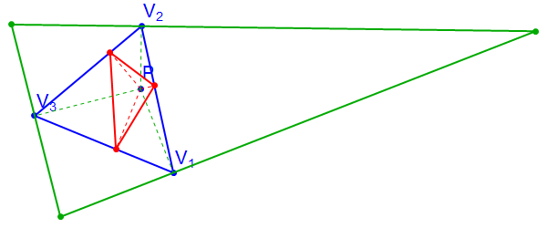

# 2 Sturm’s Theorem

In 1823, a then 20 year old Jacques Charles François Sturm (1803-1855), famously known for his Sturm–Liouville theory, proved the following remarkable fact [2]:

> The isocurves of constant area of the pedal polygon $T'$ are circles centered on the Circumcenter $X_3$.

This is aptly illustrated in Figure 7.31, page 221 in [2], with $O$ representing $X_3$:

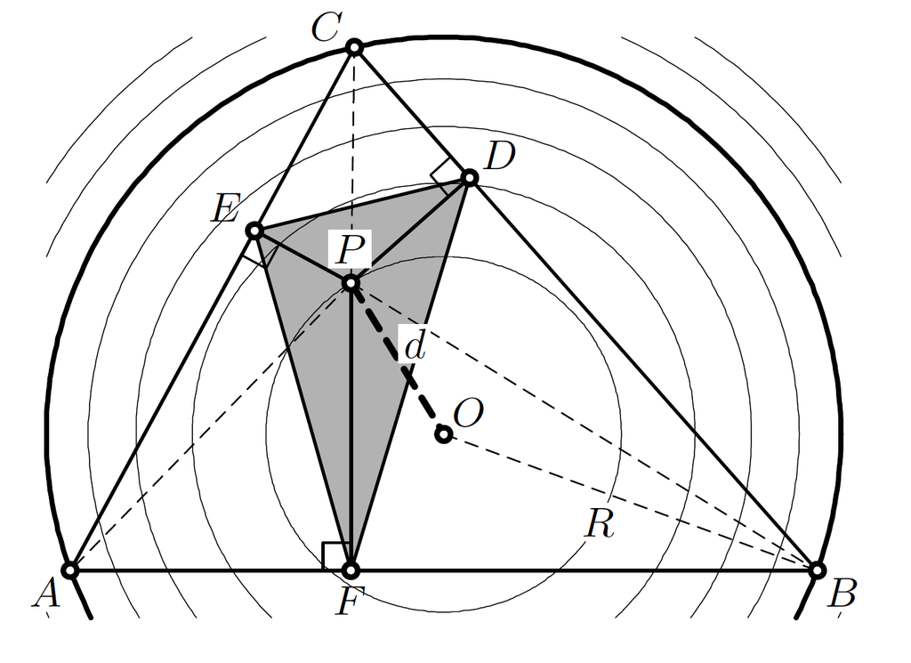

Sturm also showed that for each isocircle, the signed area $A'$ of $T'$ is given by:

$$A'=\frac{A}{4}[1-(\frac{d}{R})^2]$$

Where $A$ is the area of the reference $T$, $d$ is the radius of the isocircle, and $R$ the circumradius, respectively. The formula implies that $A'=A/4$ is maximal at $d=0$, i.e., $P=X_3$. So the extremal area pedal triangle is the pedal with respect to $X_3$, i.e., the *medial* triangle, with vertices at the midpoint of the sides of $T$.

Note that when $d<R$ the area is positive (the vertices of both $T$ and $T'$ are ordered alike). At $d=R$, $P$ is on the circumcircle and $T'$ degenerates to a zero-area triangle known as the Simson Line [1]. For $d>R$, the vertices of the pedal are in reverse order with respect to $T$ and its signed area becomes negative.

# 3 Steiner’s Curvature Centroid

$$K = \frac{\sum_{i=1}^N{\sin(2\theta_i)V_i}}{\sum_{i=1}^N{\sin(2\theta_i)}}$$

Steiner proves the area will be maximal (resp. minimal) if $\sum_i{sin(2\theta_i)}$ is positive (resp. negative). Notice that for triangles, this sum is always positive, i.e., the extremal area pedal is maximal. For parallelograms, the sum of double-angle sines is zero. Indeed, the area of pedal polygons to this shape is invariant over $P$.

**Corollary**: the Centroid of Curvature for a triangle is $X_3$, since its barycentrics are $sin(2\theta_i)$, confirming Sturm’s result.

## 3.1 Correcting X(1115)

According to [Mathworld](https://mathworld.wolfram.com/SteinerCurvatureCentroid.html) [1], the triangle center with barycentrics $\pi-\theta_i$ was named by Honsberger (1995) “Steiner’s Curvature Centroid”, listed as $X_{1115}$ on ETC [4]. This could be confusing and/or erroneous. Steiner’s Curvature Centroid for a triangle is simply $X_3$.

Note: as of July 10, 2020, Prof. Clark Kimberling has already changed $X_{1115}$ to *Exterior-Angle Curvature Centroid* [4].

# 4 Minimal-Area Antipedal

It turns out the minimal-area antipedal is the one with respect to the Orthocenter $X_4$. This is a corollary from theorem by Gallatly, page 58 [5]:

> Let $T$ be a triangle and $T'$ its pedal with respect to a point $P$. Let $T^{*}$ be the antipedal of $T$ with respect to $P^*$, the isogonal conjugate of $P$. Let $A,A',A^{*}$ denote the areas of the three mentioned triangles. Then, $A'A^{*}=A^2$.

Recall $X_4$ is the isogonal conjugate of $X_3$. Suppose another point $Y$ existed with respect to which an antipedal had area lower than $A^*$. With $A$ constant, this would imply a pedal with respect to $Y^*$, the isogonal of $Y$, of area higher than $A'$, a contradiction since $A'$ is maximal.

So the minimal antipedal is the anticomplementary triangle [1], whose area is $4A$. As before, the antipedal’s maximal-area pedal polygon will be its medial, i.e., the original $T$ itself.

## 4.1 Iso-curves of Antipedal Area

Shown below are the non-linear isocurves of antipedal triangle area with respect to points in the plane. From left to right: acute, right, and obtuse triangles are shown. The minimal-area antipedal (anticomplementary triangle) is shown green on the first and third plot, as is this triangle’s Circumcenter $X_3'$ (reference $X_4$). Note zero-area iso-curves along the circumcircle, where the antipedal triangle shrinks to a point. Also note that for the 2nd case, $X_4$ is on the right angle vertex.

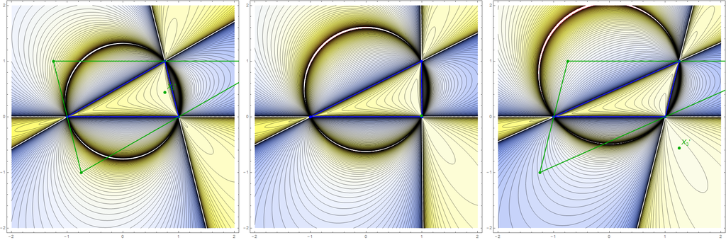

# 5 Conclusion

We salute Sturm, Steiner, and Gallatly for these wonderful results!

Comments, ideas, corrections, suggestions, and proofs contributed are very welcome. Email me us at: `dreznik _theat_ gmail _thedot_ com`.

# References

[1] Weisstein E. 2019. Mathworld. MathWorld–A Wolfram Web Resource. Available from: http://mathworld.wolfram.com,.

[2] Ostermann W A. 2012. Geometry by its history. Springer Verlag.

[3] Steiner J. 1838. Über den krümmungs-schwerpunkt ebener curven. Abhandlungen der Königlichen Akademie der Wissenshaften zu Berlin:19–91.

[4] Kimberling C. 2019. Encyclopedia of triangle centers. Available from: https://faculty.evansville.edu/ck6/encyclopedia/ETC.html,.

[5] Gallatly W. 1914. The modern geometry of the triangle. Francis Hodgson.